# EJAM Summary Report

This report summarizes environmental and residential population information for user-defined areas,  
and combines that data into indexes.

## Sample Summary Report for Polygons

##### Residents within any of the 2 specified polygons Area in Square Miles: 3.86 Population: 2,358

### Environmental and Residential Population Indicators

|  | VALUE | STATE AVERAGE | PERCENTILE IN STATE | USA AVERAGE | PERCENTILE IN USA | RATIO TO US AVG | RATIO TO STATE AVG |
| --- | --- | --- | --- | --- | --- | --- | --- |
| Pollution and Sources |  |  |  |  |  |  |  |
| Particulate Matter (PM 2.5 in ug/m3) | 6.71 | 7.24 | 21 | 8.45 | 13 | 0.8 | 0.9 |
| Ozone (ppb) | 60.9 | 59.7 | 92 | 61.8 | 52 | 1.0 | 1.0 |
| Nitrogen Dioxide (NO2) | 3.6 | 6.4 | 13 | 7.8 | 11 | 0.5 | 0.6 |
| Diesel Particulate Matter (ug/m3) | 0.086 | 0.149 | 22 | 0.191 | 23 | 0.5 | 0.6 |
| Toxic Releases to Air | 31 | 4,300 | 14 | 4,600 | 14 | 0.0 | 0.0 |
| Traffic Proximity and Volume (daily traffic count/distance to road) | 150,000 | 890,000 | 23 | 1,700,000 | 22 | 0.1 | 0.2 |
| Lead Paint Indicator (% pre-1960s housing) | 4.51% | 0.26 | 25 | 0.3 | 25 | 0.2 | 0.2 |
| Superfund Proximity (site count/km distance) | 0.12 | 0.83 | 29 | 0.39 | 62 | 0.3 | 0.1 |
| RMP Proximity (facility count/km distance) | 0.00 | 0.51 | 0 | 0.57 | 0 | 0.0 | 0.0 |
| Hazardous Waste Proximity (facility count/km distance) | 0.1 | 2.6 | 13 | 3.5 | 21 | 0.0 | 0.1 |
| Underground Storage Tanks (UST) indicator | 0.0 | 2.2 | 2 | 3.6 | 28 | 0.0 | 0.0 |
| Wastewater Discharge Indicator (toxicity-weighted concentration/distance) | 7 | 10,000 | 29 | 700,000 | 33 | 0.0 | 0.0 |
| Drinking Water Non-Compliance | 0.0 | 0.34 | 4 | 2.2 | 73 | 0.0 | 0.1 |
| Residential Population Indicators |  |  |  |  |  |  |  |
| Demographic Index USA | 0.53 | 1.39 | 20 | 1.34 | 16 | 0.4 | 0.4 |
| Supplemental Demographic Index USA | 1.63 | 1.39 | 60 | 1.64 | 55 | 1.0 | 1.1 |
| % Low Income | 12% | 25% | 26 | 30% | 21 | 0.4 | 0.5 |
| % in limited English-speaking Households | 0% | 2% | 0 | 5% | 0 | 0.0 | 0.0 |
| % Unemployed | 2% | 5% | 32 | 6% | 32 | 0.3 | 0.3 |
| % with Less Than High School Education | 4% | 9% | 36 | 11% | 31 | 0.3 | 0.4 |
| % under Age 5 | 0% | 5% | 4 | 5% | 13 | 0.1 | 0.1 |
| % over Age 64 | 23% | 22% | 65 | 18% | 75 | 1.3 | 1.1 |
| % People of Color | 16% | 38% | 26 | 40% | 31 | 0.4 | 0.4 |

## EJ Indexes

The summary and supplemental EJ indexes are a combination of environmental and residential population information.  
For each of the environmental indicators, there is an EJ Index and a Supplemental EJ Index.  
The indexes for a selected area are compared to those for all other locations in the state or nation.

|  | PERCENTILE IN STATE | PERCENTILE IN USA |  |  |  |  |
| --- | --- | --- | --- | --- | --- | --- |
| EJ Indexes |  |  |  |  |  |  |
| Particulate Matter Summary Index | 15 | 11 |  |  |  |  |
| Ozone Summary Index | 54 | 35 |  |  |  |  |
| Nitrogen Dioxide (NO2) Summary Index | 11 | 9 |  |  |  |  |
| Diesel Particulate Matter Summary Index | 17 | 17 |  |  |  |  |
| Toxic Releases to Air Summary Index | 11 | 10 |  |  |  |  |
| Traffic Proximity and Volume Summary Index | 20 | 17 |  |  |  |  |
| Lead Paint Summary Index | 18 | 18 |  |  |  |  |
| Superfund Proximity Summary Index | 30 | 61 |  |  |  |  |
| RMP Proximity Summary Index | 0 | 0 |  |  |  |  |
| Hazardous Waste Proximity Summary Index | 12 | 20 |  |  |  |  |
| Underground Storage Tanks Summary Index | 3 | 27 |  |  |  |  |
| Wastewater Discharge Summary Index | 22 | 20 |  |  |  |  |
| Drinking Water Non-Compliance Summary Index | 5 | 74 |  |  |  |  |
| Supplemental EJ Indexes |  |  |  |  |  |  |
| Particulate Matter Supplemental Summary Index | 27 | 16 |  |  |  |  |
| Ozone Supplemental Summary Index | 83 | 62 |  |  |  |  |
| Nitrogen Dioxide (NO2) Supplemental Summary Index | 18 | 13 |  |  |  |  |
| Diesel Particulate Matter Supplemental Summary Index | 33 | 27 |  |  |  |  |
| Toxic Releases to Air Supplemental Summary Index | 16 | 17 |  |  |  |  |
| Traffic Proximity and Volume Supplemental Summary Index | 35 | 26 |  |  |  |  |
| Lead Paint Supplemental Summary Index | 23 | 19 |  |  |  |  |
| Superfund Proximity Supplemental Summary Index | 40 | 73 |  |  |  |  |
| RMP Proximity Supplemental Summary Index | 0 | 0 |  |  |  |  |
| Hazardous Waste Proximity Supplemental Summary Index | 19 | 25 |  |  |  |  |
| Underground Storage Tanks Supplemental Summary Index | 3 | 26 |  |  |  |  |
| Wastewater Discharge Supplemental Summary Index | 39 | 37 |  |  |  |  |
| Drinking Water Non-Compliance Supplemental Summary Index | 6 | 73 |  |  |  |  |

| ADDITIONAL INFORMATION | VALUE | RATIO TO US AVG | RATIO TO STATE AVG |  |  |  |  |
| --- | --- | --- | --- | --- | --- | --- | --- |
| Breakdown by Population Group |  |  |  |  |  |  |  |
| % Hispanic or Latino | 6% | 0.3 | 0.6 |  |  |  |  |
| % Black or African American (non-Hispanic, single race) | 5% | 0.4 | 0.3 |  |  |  |  |
| % Asian (non-Hispanic, single race) | 1% | 0.1 | 0.2 |  |  |  |  |
| % American Indian and Alaska Native (non-Hispanic, single race) | 0% | 0 | 0 |  |  |  |  |
| % Native Hawaiian and Other Pacific Islander (non-Hispanic, single race) | 0% | 0 | 0 |  |  |  |  |
| % Other race (non-Hispanic, single race) | 0% | 0 | 0 |  |  |  |  |
| % Two or more races (non-Hispanic) | 4% | 1.3 | 1.2 |  |  |  |  |
| % White (non-Hispanic, single race) | 84% | 1.4 | 1.4 |  |  |  |  |
| Language Spoken at Home |  |  |  |  |  |  |  |
| % speaking Non English languages at home | 5% | NA | NA |  |  |  |  |
| % speaking Other Indo-European at home | 2% | NA | NA |  |  |  |  |
| % speaking Asian and Pacific Island languages at home | 0% | NA | NA |  |  |  |  |
| % speaking Other and Unspecified languages at home | 0% | NA | NA |  |  |  |  |
| % speaking English at home | 1 | NA | NA |  |  |  |  |
| % speaking Spanish at home | 3% | NA | NA |  |  |  |  |
| % speaking French at home | 0 | NA | NA |  |  |  |  |
| % speaking Russian, Polish or Other Slavic at home | 0 | NA | NA |  |  |  |  |
| % speaking Indo-European at home | 0 | NA | NA |  |  |  |  |
| % speaking Vietnamese at home | 0 | NA | NA |  |  |  |  |
| % speaking Other Asian and Pacific Island languages at home | 0 | NA | NA |  |  |  |  |
| % speaking Arabic at home | 0 | NA | NA |  |  |  |  |
| Language in Limited English Speaking Households |  |  |  |  |  |  |  |
| % speaking Spanish (as % of limited English households) | N/A | NA | NA |  |  |  |  |
| % speaking Other Indo-European languages (as % of limited English households) | N/A | NA | NA |  |  |  |  |
| % speaking Asian-Pacific Island languages (as % of limited English households) | N/A | NA | NA |  |  |  |  |
| % speaking Other languages (as % of limited English households) | N/A | NA | NA |  |  |  |  |
| Breakdown by Sex |  |  |  |  |  |  |  |
| % Males | 46% | NA | NA |  |  |  |  |
| % Females | 54% | NA | NA |  |  |  |  |

[output cut: 54 more lines]

Note: Diesel particulate matter index is from the EPA's Air Toxics Data Update, which is the Agency's ongoing, comprehensive evaluation of air toxics in the United States. This effort aims to prioritize air toxics, emission sources, and locations of interest for further study. It is important to remember that the air toxics data presented here provide broad estimates of health risks over geographic areas of the country, not definitive risks to specific individuals or locations. More information on the Air Toxics Data Update can be found at: https://www.epa.gov/haps/air-toxics-data-update

[interactive chart not shown]

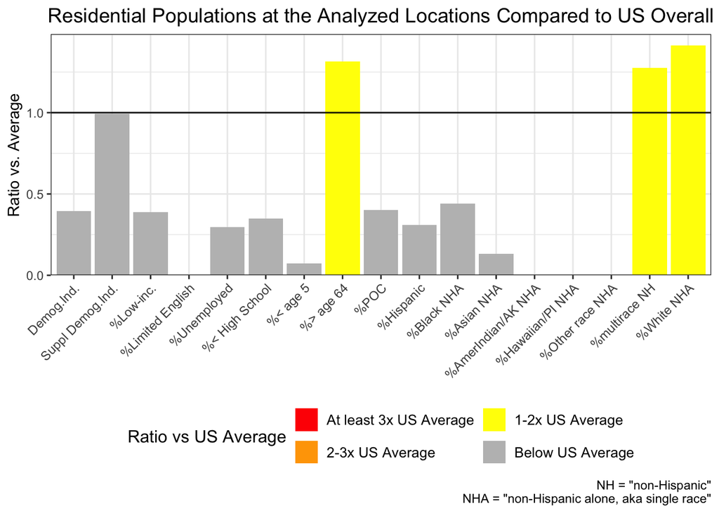

Version 2.32.6 | Report created on September 23, 2025